# Syndemic Patterns of Chronic Disease Rates Across the United States

In our previous blog post, we looked at the rates of chronic diseases, namely coronary heart disease (CHD), cancer, and stroke, and their distributions in on the macroscale (states and counties) to the microscale, tracts within cities, in the United States. In this blog post, we’ll more closely examine the relationship between these disease rates in different geographic regions, including census tracts, cities, and states. To examine these relationships, we’ll use linear regression analysis, reporting various statistics which will give us an idea of how closely related the rates of these diseases are. Understanding these relationships, or the “correlation structure” between these chronic diseases will provide us with an idea of which diseases are closely related and tend to co-occur in the same community. It will also give us an idea of how diseases manifest: coronary heart disease is a disease of the arteries of the heart. Since stroke also affects arteries, we might expect these conditions to be closely related in that communities with high rates of CHD will have high rates of stroke.

The National Center for Chronic Disease Prevention and Health Promotion (NCCDPHP) has noted that 6 in 10 Americans have one or more chronic disease (examples including heart disease, stroke, or diabetes) [1]. Better understanding the pattern of these diseases could help health care workers better manage these diseases by identifying which conditions to test for in tandem, and how to optimize medications and prevention programs. An epidemic can be loosely defined as the widespread occurrence of a disease in a community. Multiple epidemics occurring in the same space and time, and which synergistically interact with each other, could be described as a “syndemic”. Understanding correlations can help us understand how different chronic diseases interact and identify particular chronic disease syndemics in a community. We’ll perform a series of analyses to explore these correlations and identify which chronic diseases are most closely correlated at various geographic levels (census tract, city, and state).

Part 1 - Census Tract-Level Correlations  
Part 2 - City Level Correlations  
Part 3 - State Level Correlations  
Part 4 - Differences in Disease Rates between 2013-2015

## Part 1 - Census-Tract Level Correlations

First, let's look at the correlation between disease rates that the smallest, simplest geographic unit we have: the census-tract level. To do this, we will load data from the XY.ai data warehouse.

First, you will need to set up a local copy of the XY test Postgres/PostGIS database:

1. Download all the data files from here: https://github.com/andrewdeoXY/xyblog/tree/master/blog1  
2. Edit the SQL script "importxydb.sql" so that the paths on the last 5 lines correspond to the location of the TSV files that you just downloaded in step 1.  
3. Then, log into postgres (in Linux: "sudo -u postgres psql template1") and import the SQL script using the Postgres command "\i importxydb.sql"

Now, you will have a small dataset which you can use for the scripts below.

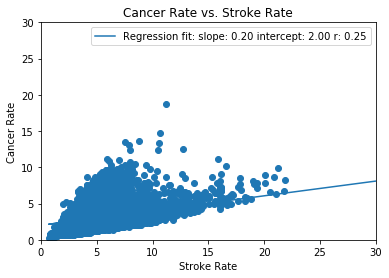

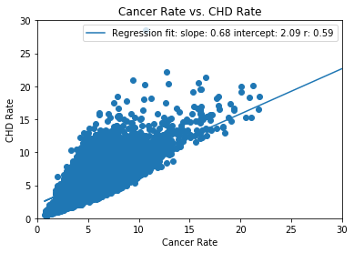

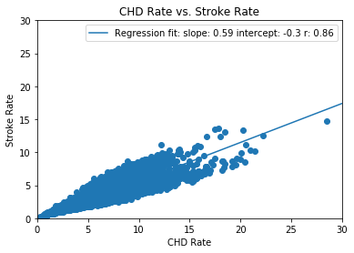

```
          Cancer    Stroke       CHD
Cancer  1.000000  0.256410  0.593654
Stroke  0.256410  1.000000  0.861475
CHD     0.593654  0.861475  1.000000
```

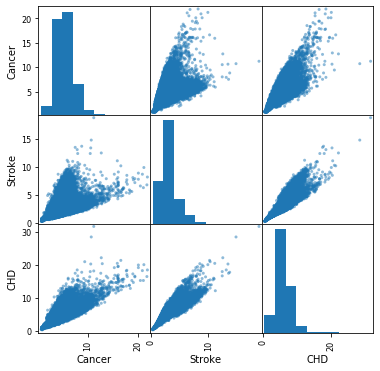

```python
import matplotlib.pyplot as plt
import numpy as np
import psycopg2
from psycopg2.extras import RealDictCursor
from sqlalchemy import func
from scipy import stats
from collections import defaultdict
import pandas as pd

%matplotlib inline

def GetDBConnection():
    hostDB = "localhost"
    tDB = "template1"
    tUser = "postgres"
    tPassword = ""
    conn = psycopg2.connect(host=hostDB, database=tDB, user=tUser, password=tPassword)
    cur = conn.cursor(cursor_factory=RealDictCursor)
    return conn, cur

# Connect to database and store in dictionary
conn, cur = GetDBConnection()

# Let's get the 500 Cities data stored in the database using an SQL query
cur.execute('Select * from edw.fivehundredcities_data')
my_record = cur.fetchall()

# We've finished querying the database, now close the connections
cur.close()
conn.close()

# Now let's convert the dictionary to numpy arrays for plotting
cancervals = np.array([])
strokevals = np.array([])
chdvals = np.array([])
datalabels = np.array([])
for trow in my_record:
    cancervals = np.append(cancervals, trow['CANCER_CrudePrev'])
    strokevals = np.append(strokevals, trow['STROKE_CrudePrev'])
    chdvals = np.append(chdvals, trow['CHD_CrudePrev'])
    datalabels = np.append(datalabels, trow['fips_place_tract'])

def ShowScatter(xval, yval, tlabels, ttitle, xtitle, ytitle):
    plt.figure()
    fig, ax1 = plt.subplots()
    (m, b) = np.polyfit(xval, yval, 1)
    correlation = np.corrcoef(xval, yval)[0,1]
    r = correlation
    tforecast = np.append(cancervals, [30])
    yp = np.polyval([m, b], tforecast)
    plt.plot(tforecast, yp, label="Regression fit: slope: " + str(m)[0:4] + " intercept: " + str(b)[0:4] + " r: " + str(r)[0:4])
    if tlabels == 'None':
        plt.scatter(xval, yval)
    if tlabels != 'None':
        plt.scatter(xval, yval, tlabels)
    plt.xlim(0, 30)
    plt.ylim(0, 30)
    plt.title(ttitle)
    plt.xlabel(xtitle)
    plt.ylabel(ytitle)
    plt.legend()
    plt.show()

# Show scatterplots
ShowScatter(cancervals, strokevals, None, 'Cancer Rate vs. Stroke Rate', 'Stroke Rate', 'Cancer Rate')
ShowScatter(cancervals, chdvals, None, 'Cancer Rate vs. CHD Rate', 'Cancer Rate', 'CHD Rate')
ShowScatter(chdvals, strokevals, None, 'CHD Rate vs. Stroke Rate', 'CHD Rate', 'Stroke Rate')

# plot correlations
df = pd.DataFrame({'Cancer': cancervals, 'Stroke': strokevals, 'CHD': chdvals})
print(df.corr())
pd.plotting.scatter_matrix(df, figsize=(6, 6))
plt.show()
```

This shows that stroke and CHD are the most strongly correlated (r = 0.86), while cancer and stroke are less correlated (r = 0.26) when we look at the census tract level.

## Part 2 - City-Level Correlations

Next, we can also examine this correlation at the city level to determine if these relationships still hold as follows:

```
          Cancer    Stroke       CHD
Cancer  1.000000  0.210950  0.520745
Stroke  0.210950  1.000000  0.864994
CHD     0.520745  0.864994  1.000000
```

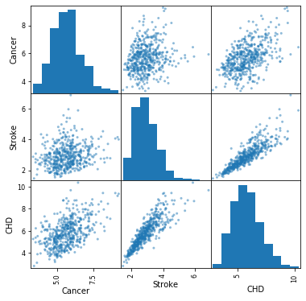

```python
# Let's take the average disease rate for each city in the 500 cities data:
finalData = defaultdict(lambda: defaultdict(float))
coordData = defaultdict(str)
cityCancer = defaultdict(float)
cityStroke = defaultdict(float)
cityCHD = defaultdict(float)
for trow in my_record:
    # we'll group by city using an identifier that includes stateabbr and placename
    tid = trow['stateabbr'] + "\t" + trow['placename']
    finalData[tid]['CancerTotal'] += trow['CANCER_CrudePrev']
    finalData[tid]['CancerCount'] += 1
    finalData[tid]['StrokeTotal'] += trow['STROKE_CrudePrev']
    finalData[tid]['StrokeCount'] += 1
    finalData[tid]['CHDTotal'] += trow['CHD_CrudePrev']
    finalData[tid]['CHDCount'] += 1
    coordData[tid] = str(trow['Geolocation'])

# and take the average:
for trow in finalData:
    cityCancer[trow] = finalData[trow]['CancerTotal'] / finalData[trow]['CancerCount']
    cityStroke[trow] = finalData[trow]['StrokeTotal'] / finalData[trow]['StrokeCount']
    cityCHD[trow] = finalData[trow]['CHDTotal'] / finalData[trow]['CHDCount']

# plot correlations by city:
df2 = pd.DataFrame({'Cancer': cityCancer, 'Stroke': cityStroke, 'CHD': cityCHD})
print(df2.corr())
pd.plotting.scatter_matrix(df2, figsize=(6, 6))
plt.show()
```

We can take this analysis further, and "zoom in" on the relationship between stroke and CHD. We'll highlight cities in "stroke belt" states in red using the "ScatterWithLabels" function below:

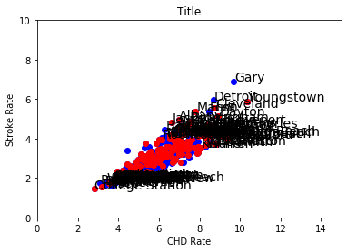

```python
# plot correlations by city:
colordata = defaultdict(str)
df3 = pd.DataFrame({'Cancer': cityCancer, 'Stroke': cityStroke, 'CHD': cityCHD, 'Color': colordata})

def ScatterWithLabels(data, xval, yval, ttitle, xtitle, ytitle, xlow, xhigh, ylow, yhigh, txlimlo, txlimhi, tylimlo, tylimhi):

    # annotate each point with city name
    strokebelt = []
    strokecheck = ["AL", "AR", "FL", "GA", "KY", "LA", "MS", "NC", "OH", "PA", "SC", "TN", "TX", "VA", "WV"]
    plt.scatter(data[[xval]], data[[yval]], c="blue")

    for index, row in data.iterrows():

        # now let's pick out cities that are in stroke-belt states (the IDs are "stateabbr \t placename")
        tlabel = index
        if tlabel.find("\t") != -1:
            tdata = tlabel.split("\t")
            tlabel = tdata[1]
            if tdata[0] in strokecheck:
                strokebelt.append(index)

        # if the ID is just "state" for the analysis below...
        if tlabel.find("\t") == -1:
            if index in strokecheck:
                strokebelt.append(index)

        if (xlow == 0) | ((row[xval] < xlow) | (row[xval] >= xhigh)) | ((row[yval] < ylow) | (row[yval] >= yhigh)):
            plt.text(row[xval] * (1 + 0.005), row[yval] * (1 + 0.005) , tlabel, fontsize=14)

    # highlight stroke belt
    rowData = data.loc[strokebelt, : ]
    plt.scatter(rowData[[xval]], rowData[[yval]], c="red")

    plt.xlim(txlimlo, txlimhi)
    plt.ylim(tylimlo, tylimhi)
    plt.title(ttitle)
    plt.xlabel(xtitle)
    plt.ylabel(ytitle)
    plt.rcParams["figure.figsize"] = (15,15)
    plt.show()

ScatterWithLabels(df3, 'CHD', 'Stroke', 'Title', 'CHD Rate', 'Stroke Rate', 3, 8, 2, 4, 0, 15, 0, 10)
```

From the city plot above, the same correlation pattern can be seen, with CHD correlating the strongest with stroke, and the weakest correlations seen between cancer and stroke.

## Part 3 - State-Level Correlations

Finally, we can also look at the state level to see if we see the same correlation pattern. Again, we will highlight the states that are part of the stroke belt in red and see if they end up having high stroke and CHD rates.

```
          Cancer    Stroke       CHD
Cancer  1.000000  0.098454  0.528406
Stroke  0.098454  1.000000  0.752526
CHD     0.528406  0.752526  1.000000
```

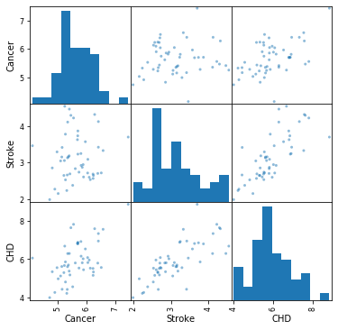

```python
# Now let's look at the state level for correlations:
finalData.clear()

coordData = defaultdict(str)
stateCancer = defaultdict(float)
stateStroke = defaultdict(float)
stateCHD = defaultdict(float)
for trow in my_record:
    # change the identifier so we analyze data at the state level using stateabbr
    tid = trow['stateabbr']
    finalData[tid]['CancerTotal'] += trow['CANCER_CrudePrev']
    finalData[tid]['CancerCount'] += 1
    finalData[tid]['StrokeTotal'] += trow['STROKE_CrudePrev']
    finalData[tid]['StrokeCount'] += 1
    finalData[tid]['CHDTotal'] += trow['CHD_CrudePrev']
    finalData[tid]['CHDCount'] += 1

# and take the average:
for trow in finalData:
    stateCancer[trow] = finalData[trow]['CancerTotal'] / finalData[trow]['CancerCount']
    stateStroke[trow] = finalData[trow]['StrokeTotal'] / finalData[trow]['StrokeCount']
    stateCHD[trow] = finalData[trow]['CHDTotal'] / finalData[trow]['CHDCount']

# plot correlations by city:
df4 = pd.DataFrame({'Cancer': stateCancer, 'Stroke': stateStroke, 'CHD': stateCHD})
print(df4.corr())
pd.plotting.scatter_matrix(df4, figsize=(6, 6))
plt.show()
```

In the correlation plot, again the highest correlations are noted for stroke and CHD. We can investigate the relationship between stroke and CHD further using a scatterplot, highlighting the stroke belt states. We can use the "ScatterWithLabels" function again to visualize this:

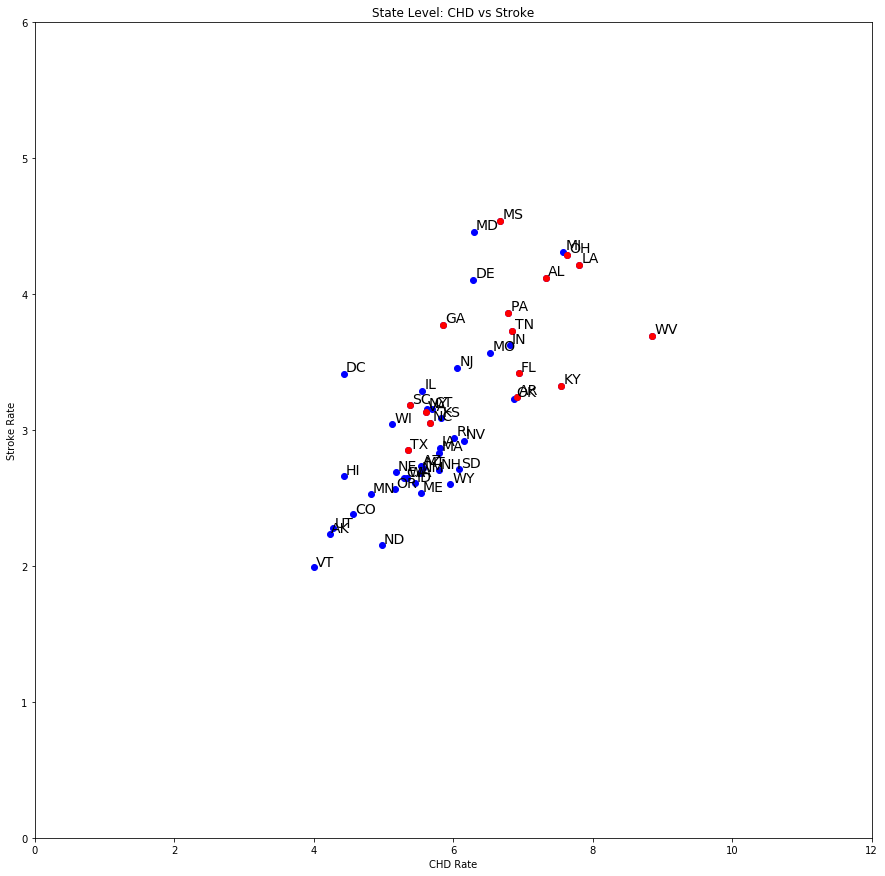

```python
# show labelled scatter plot
ScatterWithLabels(df4, 'CHD', 'Stroke', 'State Level: CHD vs Stroke', 'CHD Rate', 'Stroke Rate', 0, 0, 0, 0, 0, 12, 0, 6)
```

From the last scatterplot, we can see that many of the red points, which represent the stroke belt, are in the upper-right hand portion of the graph. This again confirms the existence of the stroke belt, that there are high rates of stroke in those states, and high rates of CHD.

## Part 4 - Differences in Disease Rates

```python
# Connect to database and get rate data
conn3, cur3 = GetDBConnection()

# Let's get the 500 Cities data stored in the database using an SQL query - from edw.fivehundredcities_data_2015_2016
cur3.execute('Select * from edw.fivehundredcities_data_2015_2016')
datafrom2016 = cur3.fetchall()

cur3.close()
conn3.close()

# Now subtract the 2015-2016 data (in datafrom2016) from our 2013 data (finalData):
finalData.clear()
cancerDiff = defaultdict(float)
strokeDiff = defaultdict(float)
chdDiff = defaultdict(float)
for trow in datafrom2016:
    tid = trow['stateabbr'] + "\t" + trow['placename']
    finalData[tid]['CancerTotal'] += trow['CANCER_CrudePrev'] - cityCancer[tid]
    finalData[tid]['CancerCount'] += 1
    finalData[tid]['StrokeTotal'] += trow['STROKE_CrudePrev'] - cityStroke[tid]
    finalData[tid]['StrokeCount'] += 1
    finalData[tid]['CHDTotal'] += trow['CHD_CrudePrev'] - cityCHD[tid]
    finalData[tid]['CHDCount'] += 1

# and take the average:
for trow in finalData:
    cancerDiff[trow] = finalData[trow]['CancerTotal'] / finalData[trow]['CancerCount']
    strokeDiff[trow] = finalData[trow]['StrokeTotal'] / finalData[trow]['StrokeCount']
    chdDiff[trow] = finalData[trow]['CHDTotal'] / finalData[trow]['CHDCount']
```

After extracting the data, we can now visualize the difference in rates as follows:

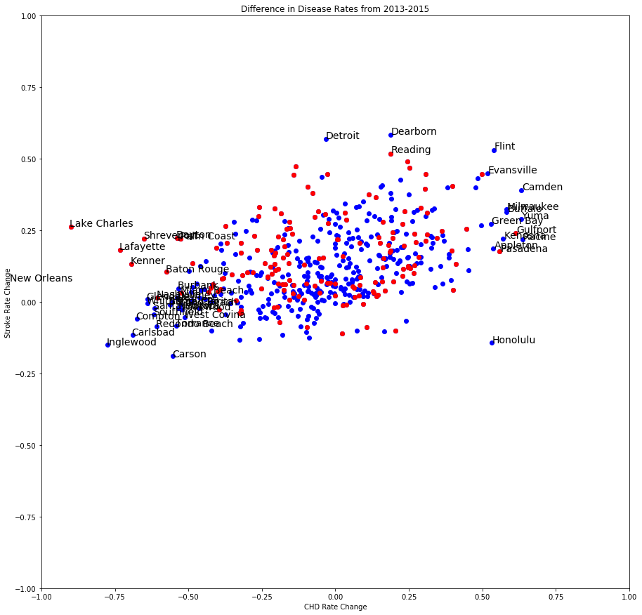

```python
# plot correlations by city:
df6 = pd.DataFrame({'Cancer': cancerDiff, 'Stroke': strokeDiff, 'CHD': chdDiff})
ScatterWithLabels(df6, 'CHD', 'Stroke', 'Difference in Disease Rates from 2013-2015', 'CHD Rate Change', 'Stroke Rate Change', -0.5, 0.5, -0.5, 0.5, -1, 1, -1, 1)
```

From the above scatter plot, some cities in the stroke belt (red dots) showed improvement, reducing their stroke and CHD rates. However, some places outside the stroke belt, such as Dearborn and Flint (in Michigan) showed increases in stroke and CHD rates.

## Conclusions

We were able to visualize the correlations between different chronic diseases at the census tract, city, and state levels, noting that similar patterns of correlation exist at every geographic level. By plotting the change in disease rates, we can also identify which cities are doing well at improving the health of their population, and which cities face challenges.

## References

[1] CDC, National Center for Chronic Disease Prevention and Health Promotion (NCCDPHP). Downloaded from https://www.cdc.gov/chronicdisease/index.htm on January 2nd, 2019.